# Experimentální ekonomie

*Zpětná vazba, júlový turnus Discover*

## Hodnocení kurzu

Průměrná známka:

| Blok setkání | Průměrná známka |
| --- | --- |
| A | 1.24 |

### Hodnocení po dnech

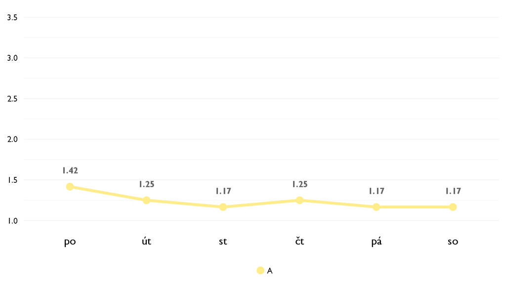

### Co se na kurzu líbilo

- Teorie her
- Dozvedať sa nové poznatky z oblasti, ktorá ma poslednou dobou zaujíma, no moc som toho o nej nevedel.
- všetko
- Hlavne to, že sme mali všetko vysvetlené pomocou hier, ktoré sme si sami vyskúšali a tým sme mohli lepšie pochopiť, prečo to tak funguje.
- Hraní her z teorie her.
- Velmi ma zaujalo ako velmi ovplyvnuje ekonomia ludi a kolko roznych pohladov moze byt na jeden problem a kolko z nich a da jednoduchsie a lepsie vyriesit keby sme sa len viac vyznali v ekonomii.
- Game theory, diskusie
- Teorie her, experimenty, chybne grafy a ruzne hry
- Nejvic se mi libilo to, ze jsem se dozvedel neco noveho o ekonomii a zlepsil jsem, doufam, svoji financni gramotnost.
- Nové veci, postupná práca s lektorom, reality reflection
- Posuzování grafů
- Lektorka! Pověst ji předcházela a fakt byla super, fantastická, boží, jak o ní lidé mluvili.

### Co na kurzu změnit

- Více ekonomické teorie
- Nic.
- Mnozstvo teorie
- Mozna by to chtelo zakomponovat do kurzu technologie jako je pocitac, a tim bychom udelali kurz vice zajimavy.
- Môže toho byť aj viac
- Ať se lektorka více usmívá!!!

## Hodnocení lektora

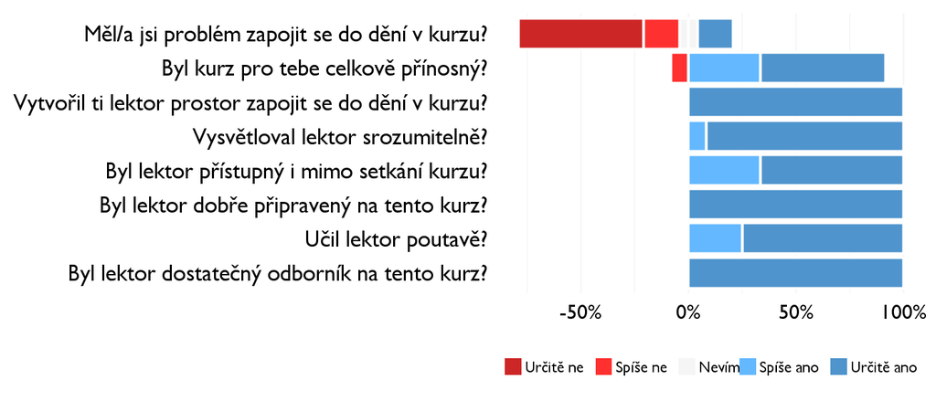

### Komentáře k lektorovi

- Usmívat se, usmívat se, usmívat se! A mít vícě času na studenty i třeba večer na diskuzi.

## Náročnost kurzu

### **Jak hodnotíš náročnost…**

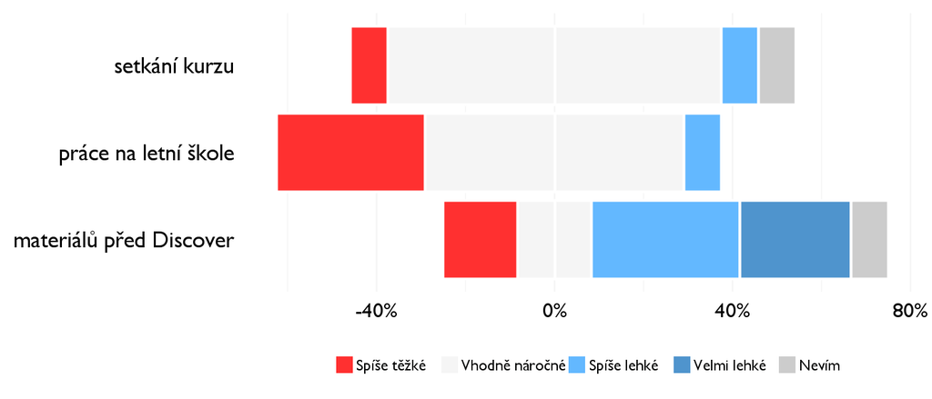

## Didaktika

### Jak lektor učí a měl by to změnit?

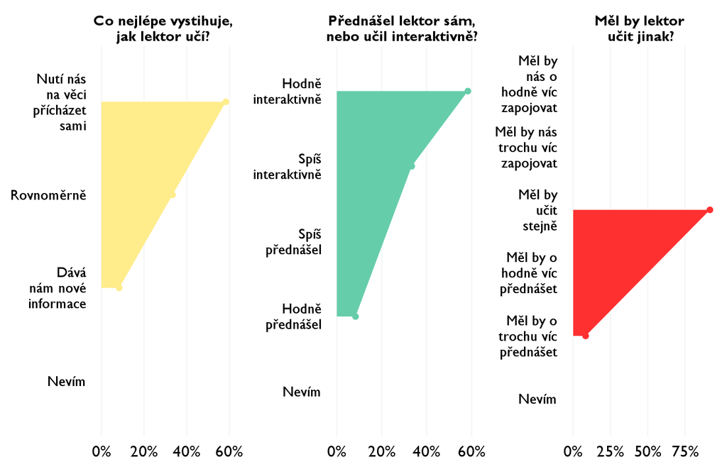

### Jak se studentům nejlépe učí?

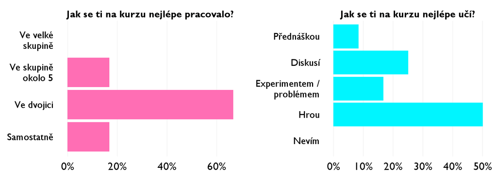

## Ovlivnil tě kurz nějak?

**Pokud ano, jak? Pokud ne, proč ne?**

- Vysvětlil mi výkumné metody v ekonomii
- Utvrdil ma v mojom záujme o danú problematiku.
- v pohľade na ľudí
- Určite áno, hlavne v tom, že viem lepšie predpokladať, ako sa budú ľudia v rôznych situáciach správať.
- Utvrdil mě v tom, co chci studovat.
- v tom co vlastne ekonomia robi a ako velmi suvisi s nasim beznym zivotom a kedze uvazujem o buducom studovani ekonomie tak ma v tom mierne utvrdil.
- Zistil som ako sa debatuje
- utvorila jsem si novy obraz ekonomie nejen jako rigidni matematicky vedy, ale vicerozmerove slozite a dynamicke discipliny
- Urcite se budu vyvarovat nejakym iracionalnim rozhodnutim, ktere delaji lide s penezi
- Uzrejmenie reality, hlbší insight do témy o ktorú mám záujem
- Možná v strategiích her
- Ovlivnil mě v tom, jak všude se daří aplikovat ekonomické myšlení, jak moc se to všude hodí do praktických situací.